# Trabajo Final - GRUPO 14

Lopez Valeria - Alvarez Jorge

## Introducción

Los datos pertenecen a reseñas de vinos. Los datos provienen de WineEnthusiast y fueron tomados por Zack Thoutt. Se tomaron durante la semana del 15 de junio de 2017.

https://www.kaggle.com/datasets/zynicide/wine-reviews https://www.winemag.com/?s=&drink_type=wine https://github.com/zackthoutt/wine-deep-learning/blob/master/README.md

## Exploración de los datos

```r
# Código para cargar o leer los datos

vinos<- read_csv("datos/vinos.csv")
```

Tiene las siguientes variables:

```r
names(vinos) #La función names() por su parte, nos devuelve los nombres de las variables
```

```
##  [1] "pais"          "nombre"        "puntos"        "precio"
##  [5] "provincia"     "region_1"      "region_2"      "variedad"
##  [9] "vina"          "titulo_resena"
```

```r
cantidad_obs_vinos <-count(vinos) #La funcion count cuenta el nro de filas
```

Se pudieron encontrar en la tabla vinos 129971 observaciones

```r
cantidad_variables_vinos <-length(vinos) # La funcion lengrh devuelve el tamaño de un elemento
```

Posee 10 Variables

## Algunas cosas para mostrar:

```r
valor_medio_precio <- summarise(vinos, valor_medio = mean(precio,na.rm = TRUE))
```

El valor medio de la variable precio es 35.3633891

```r
desvio_std_precio <- summarise(vinos, desvio_std = sd(precio,na.rm = TRUE))
```

El desvío estándar de la variable precio es 41.0222177

- ¿Cuál es su rango (valor máximo y valor mínimo)?

```r
summarise(vinos, Valor_max = max(precio,na.rm = TRUE))
```

```
## # A tibble: 1 × 1
##   Valor_max
##       <dbl>
## 1      3300
```

```r
summarise(vinos, Valor_min = min(precio,na.rm = TRUE))
```

```
## # A tibble: 1 × 1
##   Valor_min
##       <dbl>
## 1         4
```

Variable PUNTOS - ¿Cuál es su valor medio y desvío estándard?

```r
summarise(vinos, valor_medio = mean(puntos,na.rm = TRUE))
```

```
## # A tibble: 1 × 1
##   valor_medio
##         <dbl>
## 1        88.4
```

```r
summarise(vinos, desvio_std = sd(puntos,na.rm = TRUE))
```

```
## # A tibble: 1 × 1
##   desvio_std
##        <dbl>
## 1       3.04
```

- ¿Cuál es su rango (valor máximo y valor mínimo)?

```r
summarise(vinos,
          Valor_max = max(puntos,na.rm = TRUE),
          Valor_min = min(puntos,na.rm = TRUE))
```

```
## # A tibble: 1 × 2
##   Valor_max Valor_min
##       <dbl>     <dbl>
## 1       100        80
```

- ¿Hay alguna anomalía que sugiera que hay datos incorrectos? Valores imposibles (como valores negativos en una variable que sólo puede ser positiva) o poco creíbles.
- ¿Cuántas observaciones hay por cada grupo? ¿Cuántos valores faltantes? ¿Hay diferencias?

-Cantidad de observaciones por la variable PAIS

```r
vinos|>
group_by(pais)|>
  summarise(n=n())|>
 knitr::kable()
```

| pais | n |
| --- | --- |
| Alemania | 2165 |
| Argentina | 3800 |
| Armenia | 2 |
| Australia | 2329 |
| Austria | 3345 |
| Bosnia y Herzegovina | 2 |
| Brazil | 52 |
| Bulgaria | 141 |
| Canadá | 257 |
| Chile | 4472 |
| China | 1 |
| Chipre | 11 |
| Croacia | 73 |
| Egipto | 1 |
| Eslovaquia | 1 |
| Eslovenia | 87 |
| España | 6645 |
| Estados Unidos | 54504 |
| Francia | 22093 |
| Georgia | 86 |
| Grecia | 466 |
| Hungría | 146 |
| India | 9 |
| Inglaterra | 74 |
| Israel | 505 |
| Italia | 19540 |
| Luxemburgo | 6 |
| Líbano | 35 |
| Macedonia | 12 |
| Marruecos | 28 |
| Moldavia | 59 |
| México | 70 |
| Nueva Zelanda | 1419 |
| Perú | 16 |
| Portugal | 5691 |
| República Checa | 12 |
| Rumania | 120 |
| Serbia | 12 |
| Sudáfrica | 1401 |
| Suiza | 7 |
| Turquía | 90 |
| Ucrania | 14 |
| Uruguay | 109 |
| NA | 63 |

- Cantidad de observaciones por la variable NOMBRE

```r
vinos|>
group_by(nombre)|>
  summarise(n=n())
```

```
## # A tibble: 37,980 × 2
##    nombre                                n
##    <chr>                             <int>
##  1 #19 Phantom Limb Belmont Vineyard     1
##  2 #50 Mon Chou                          1
##  3 #SocialSecret                         2
##  4 %@#$!                                 1
##  5 &                                     2
##  6 '61 Rosé                              1
##  7 'A Rina                               1
##  8 'Blend 105' Red Wine                  1
##  9 'Na Vota                              2
## 10 'P'                                   1
## # ℹ 37,970 more rows
```

-Cantidad de observaciones por la variable PUNTOS

```r
vinos|>
group_by(puntos)|>
  summarise(n=n())|>
  knitr::kable()
```

| puntos | n |
| --- | --- |
| 80 | 397 |
| 81 | 692 |
| 82 | 1836 |
| 83 | 3025 |
| 84 | 6480 |
| 85 | 9530 |
| 86 | 12600 |
| 87 | 16933 |
| 88 | 17207 |
| 89 | 12226 |
| 90 | 15410 |
| 91 | 11359 |
| 92 | 9613 |
| 93 | 6489 |
| 94 | 3758 |
| 95 | 1535 |
| 96 | 523 |
| 97 | 229 |
| 98 | 77 |
| 99 | 33 |
| 100 | 19 |

-Cantidad de observaciones por la variable PRECIO

```r
vinos|>
group_by(precio)|>
summarise(n=n())|>
knitr::kable()
```

| precio | n |
| --- | --- |
| 4 | 11 |
| 5 | 46 |
| 6 | 120 |
| 7 | 433 |
| 8 | 892 |
| 9 | 1339 |
| 10 | 3439 |
| 11 | 2058 |
| 12 | 3934 |
| 13 | 3549 |
| 14 | 3215 |
| 15 | 6066 |
| 16 | 3547 |
| 17 | 3053 |
| 18 | 4883 |
| 19 | 2816 |
| 20 | 6940 |
| 21 | 1232 |
| 22 | 3357 |
| 23 | 1715 |
| 24 | 2826 |
| 25 | 5805 |
| 26 | 1706 |
| 27 | 1193 |
| 28 | 2942 |
| 29 | 1387 |
| 30 | 4951 |
| 31 | 276 |
| 32 | 1963 |
| 33 | 668 |

[output cut: 361 more lines]

-Cantidad de observaciones por la variable PROVINCIA Se puede concluir que la provincia con mayor produccion de vinos es California

```r
vinos|>
group_by(provincia)|>
summarise(n=n()) |>
arrange(desc(n))|>
knitr::kable()
```

| provincia | n |
| --- | --- |
| California | 36247 |
| Washington | 8639 |
| Bordeaux | 5941 |
| Tuscany | 5897 |
| Oregon | 5373 |
| Burgundy | 3980 |
| Northern Spain | 3851 |
| Piedmont | 3729 |
| Mendoza | 3264 |
| Veneto | 2716 |
| New York | 2688 |
| Alsace | 2440 |
| Northeastern Italy | 2138 |
| Loire Valley | 1856 |
| Sicily & Sardinia | 1797 |
| Champagne | 1613 |
| Southwest France | 1503 |
| South Australia | 1349 |
| Southern Italy | 1349 |
| Provence | 1346 |
| Douro | 1281 |
| Central Italy | 1233 |
| Catalonia | 1164 |
| Rhône Valley | 1081 |
| Beaujolais | 1044 |
| Mosel | 1039 |
| Alentejano | 937 |
| Valle de Colchagua | 830 |
| Marlborough | 798 |
| Virginia | 777 |

[output cut: 397 more lines]

-Cantidad de observaciones por la variable REGION_1

No se puede llegar a una conclusion ya que se presentan mucho datos NA

```r
vinos|>
group_by(region_1)|>
summarise(n=n()) |>
arrange(desc(n))|>
 knitr::kable()
```

| region_1 | n |
| --- | --- |
| NA | 21247 |
| Napa Valley | 4480 |
| Columbia Valley (WA) | 4124 |
| Russian River Valley | 3091 |
| California | 2629 |
| Paso Robles | 2350 |
| Mendoza | 2301 |
| Willamette Valley | 2301 |
| Alsace | 2163 |
| Champagne | 1613 |
| Barolo | 1599 |
| Finger Lakes | 1565 |
| Sonoma Coast | 1474 |
| Brunello di Montalcino | 1470 |
| Rioja | 1469 |
| Sonoma County | 1246 |
| Toscana | 1197 |
| Walla Walla Valley (WA) | 1066 |
| Chianti Classico | 1062 |
| Santa Barbara County | 1000 |
| Carneros | 999 |
| Yakima Valley | 997 |
| Sta. Rita Hills | 975 |
| Dry Creek Valley | 939 |
| Sicilia | 925 |
| Côtes de Provence | 859 |
| Santa Ynez Valley | 812 |
| Santa Lucia Highlands | 806 |
| Lodi | 803 |
| Barbaresco | 794 |

[output cut: 1200 more lines]

-Cantidad de observaciones por la variable REGION_2 No se puede llegar a una conclusion ya que se presentan mucho datos NA

```r
vinos|>
group_by(region_2)|>
summarise(n=n()) |>
arrange(desc(n))|>
 knitr::kable()
```

| region_2 | n |
| --- | --- |
| NA | 79460 |
| Central Coast | 11065 |
| Sonoma | 9028 |
| Columbia Valley | 8103 |
| Napa | 6814 |
| Willamette Valley | 3423 |
| California Other | 2663 |
| Finger Lakes | 1777 |
| Sierra Foothills | 1462 |
| Napa-Sonoma | 1169 |
| Central Valley | 1062 |
| Southern Oregon | 917 |
| Oregon Other | 727 |
| Long Island | 680 |
| North Coast | 584 |
| Washington Other | 534 |
| South Coast | 272 |
| New York Other | 231 |

-Cantidad de observaciones por la variable VARIEDAD

La variedad de uvas mas usada para la fabricacion de vinos es la Pinot Noir

```r
vinos|>
group_by(variedad)|>
  summarise(n=n()) |>
  arrange(desc(n))|>
   knitr::kable()
```

| variedad | n |
| --- | --- |
| Pinot Noir | 13272 |
| Chardonnay | 11753 |
| Cabernet Sauvignon | 9472 |
| Ensamblaje Tinto | 8946 |
| Bordeaux-style Red Blend | 6915 |
| Riesling | 5189 |
| Sauvignon Blanc | 4967 |
| Syrah | 4142 |
| Rosé | 3564 |
| Merlot | 3102 |
| Nebbiolo | 2804 |
| Zinfandel | 2714 |
| Sangiovese | 2707 |
| Malbec | 2652 |
| Portuguese Red | 2466 |
| Ensamblaje Blanco | 2360 |
| Sparkling Blend | 2153 |
| Tempranillo | 1810 |
| Ensamblaje Tinto Tipo Rhône | 1471 |
| Pinot Gris | 1455 |
| Champagne Ensamblaje | 1396 |
| Cabernet Franc | 1353 |
| Grüner Veltliner | 1345 |
| Portuguese White | 1159 |
| Bordeaux-style White Blend | 1066 |
| Pinot Grigio | 1052 |
| Gamay | 1025 |
| Gewürztraminer | 1012 |
| Viognier | 996 |
| Shiraz | 836 |

[output cut: 678 more lines]

-Cantidad de observaciones por la variable ViÑA

```r
vinos|>
group_by(vina)|>
  summarise(n=n())|>
  knitr::kable()
```

| vina | n |
| --- | --- |
| 1+1=3 | 6 |
| 10 Knots | 4 |
| 100 Percent Wine | 3 |
| 1000 Stories | 2 |
| 1070 Green | 1 |
| 10Span | 4 |
| 12 Linajes | 8 |
| 12C Wines | 5 |
| 13 Celsius | 1 |
| 14 Hands | 67 |
| 16X20 | 2 |
| 1752 Signature Wines | 1 |
| 1789 Wines | 1 |
| 181 | 1 |
| 18401 Cellars | 5 |
| 1848 Winery | 6 |
| 1850 | 3 |
| 19 Crimes | 1 |
| 1912 Winemakers | 8 |
| 2 Copas | 1 |
| 2 Lads | 7 |
| 2 Up | 4 |
| 21 Grams | 2 |
| 24 Knots | 1 |
| 240 Days | 3 |
| 25 Lagunas | 1 |
| 29 & Oak Wines | 5 |
| 2Hawk | 7 |
| 2Plank | 6 |
| 2nd Chance | 3 |

[output cut: 16727 more lines]

-Cantidad de observaciones por la variable titulo_resena

```r
vinos|>
group_by(titulo_resena)|>
  summarise(n=n())
```

```
## # A tibble: 118,840 × 2
##    titulo_resena                                                               n
##    <chr>                                                                   <int>
##  1 1+1=3 2008 Rosé Cabernet Sauvignon (Penedès)                                1
##  2 1+1=3 NV Brut Sparkling (Cava)                                              2
##  3 1+1=3 NV Cygnus Brut Nature Reserva Made With Organic Grapes Sparkling…     2
##  4 1+1=3 NV Rosé Sparkling (Cava)                                              1
##  5 10 Knots 2006 Beachcomber White (Paso Robles)                               1
##  6 10 Knots 2006 Chardonnay (Santa Barbara County)                             1
##  7 10 Knots 2009 Moonraker Grenache (Paso Robles)                              1
##  8 10 Knots 2010 Viognier (Paso Robles)                                        1
##  9 100 Percent Wine 2012 All Profits to Charity Red (California)               1
## 10 100 Percent Wine 2014 All Profits to Charity Sauvignon Blanc (Californ…     1
## # ℹ 118,830 more rows
```

Definición valores faltantes en R,se entiende valores que debieron haberse registrado, pero no lo fueron. R almacena los valores faltantes como NA, lo que significa Not Available

Primero preguntamos ¿Hay valores faltantes?

```r
any_na(vinos) #La función any_na() por su parte, nos devuelve TRUE si hay valores faltantes
```

```
## [1] TRUE
```

Obtengo los valores faltantes de toda la tabla vinos

```r
sum(is.na(vinos))
```

```
## [1] 147295
```

Obtengo los valores faltantes para cada variable con la función apply

```r
apply(X = is.na(vinos), MARGIN = 2, FUN = sum)
```

```
##          pais        nombre        puntos        precio     provincia
##            63         37465             0          8996            63
##      region_1      region_2      variedad          vina titulo_resena
##         21247         79460             1             0             0
```

¿Hay diferencias? Si existen diferencias. Donde más datos faltantes hay es en la variable ‘nombre’ y ‘region_2’. Los datos faltantes son datos que deberían estar pero no fueron registrados.

-Cantidad de observaciones por la variable PUNTOS, ordenado de forma decreciente

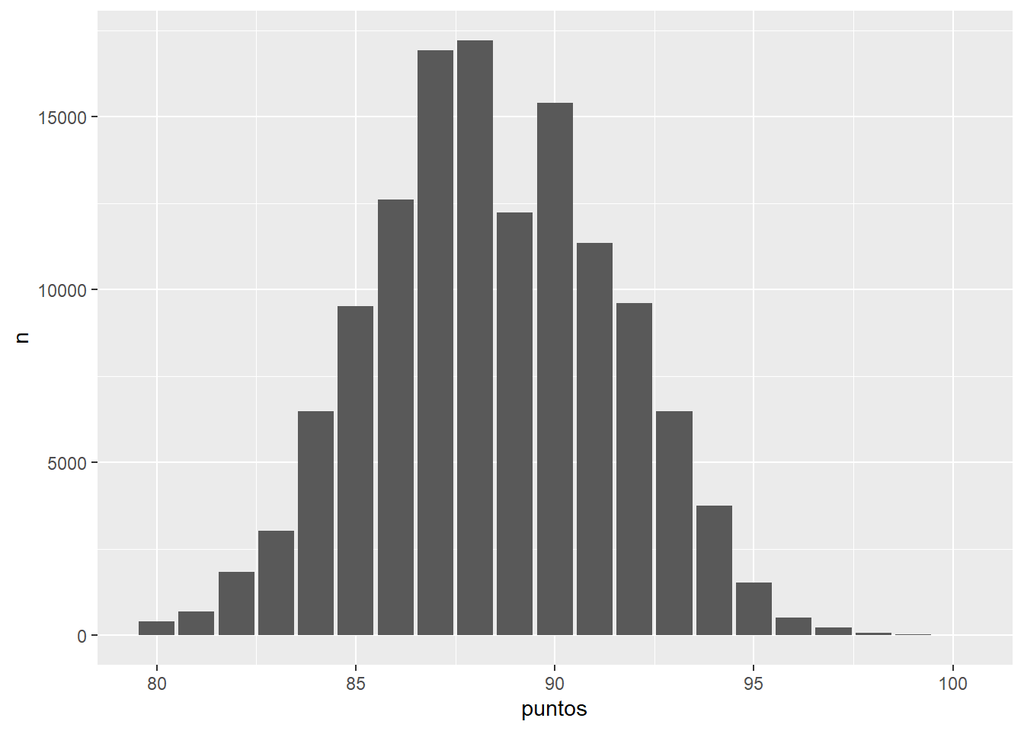

```r
 vinos|>
  group_by(puntos)|>
  summarise(n=n()) |>
  arrange(desc(puntos)) |>
 ggplot(mapping = aes(x= puntos, y = n))+
   geom_col()
```

- Cantidad de observaciones por PAIS, ordenado en forma decreciente para saber que país tiene más observaciones.

Aqui ya podemos ver que unos de los mayores productores de vino es EEUU.

```r
vinos|>
group_by(pais)|>
  summarise(n=n())|>
  arrange(desc(n))
```

```
## # A tibble: 44 × 2
##    pais               n
##    <chr>          <int>
##  1 Estados Unidos 54504
##  2 Francia        22093
##  3 Italia         19540
##  4 España          6645
##  5 Portugal        5691
##  6 Chile           4472
##  7 Argentina       3800
##  8 Austria         3345
##  9 Australia       2329
## 10 Alemania        2165
## # ℹ 34 more rows
```

## Hipótesis

“Existe relación entre el precio del vino y la puntuación?”

Si bien no es particularmente esclarecedor, muestra que hay cierta concentración de vinos de menor precio en el rango de 85 a 92,5 puntos.

Podemos deducir mediante el grafico que se produce una concentracion de vinos de menor precio en el rango comprendido entre los 85 y 90 puntos aproximadamente, se limito la muestra para vinos por debajo de los $200.

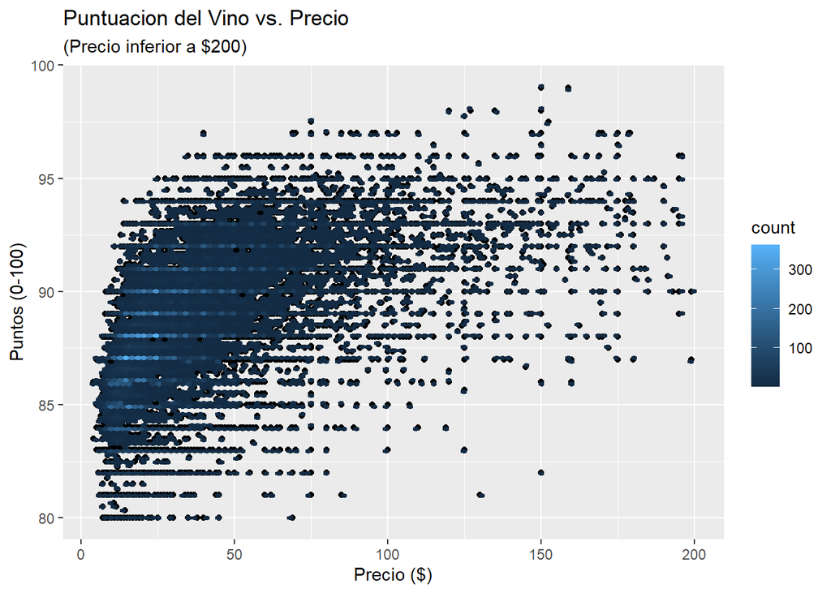

```r
# Limitamos el precio a $200
vinos2 <- vinos |>
  group_by(nombre)|>
  summarise(valor_medio_precio=mean(precio,na.rm=TRUE),valor_medio_puntos=mean(puntos,na.rm=TRUE) )|>
  filter(valor_medio_precio < 200 & !is.na(valor_medio_precio))

# Datos
vinos2 |>
  ggplot(aes(valor_medio_precio, valor_medio_puntos)) +
  geom_point(position="jitter") +
  geom_hex(bins = 100) +
  labs(title="Puntuacion del Vino vs. Precio",
       subtitle="(Precio inferior a $200)",
       x="Precio ($)", y="Puntos (0-100)")
```

Se desea saber cómo se comparan los países en términos de puntos para cada vino. ¿Hay alguna diferencia en la calidad del vino entre cada país? En particular, se va comparar los vinos de EEUU con los vinos italianos y franceses. Se usara un diagrama de caja que también incluye la media.

¿Existe relación entre el país de donde proviene el vino y la puntuación?.

```r
 vinos_pais <- group_by(vinos,pais) |>
summarise(n= n()) |>
filter(n>30)|>
arrange(desc(n))
head(vinos_pais,20)|>
 knitr::kable()
```

| pais | n |
| --- | --- |
| Estados Unidos | 54504 |
| Francia | 22093 |
| Italia | 19540 |
| España | 6645 |
| Portugal | 5691 |
| Chile | 4472 |
| Argentina | 3800 |
| Austria | 3345 |
| Australia | 2329 |
| Alemania | 2165 |
| Nueva Zelanda | 1419 |
| Sudáfrica | 1401 |
| Israel | 505 |
| Grecia | 466 |
| Canadá | 257 |
| Hungría | 146 |
| Bulgaria | 141 |
| Rumania | 120 |
| Uruguay | 109 |
| Turquía | 90 |

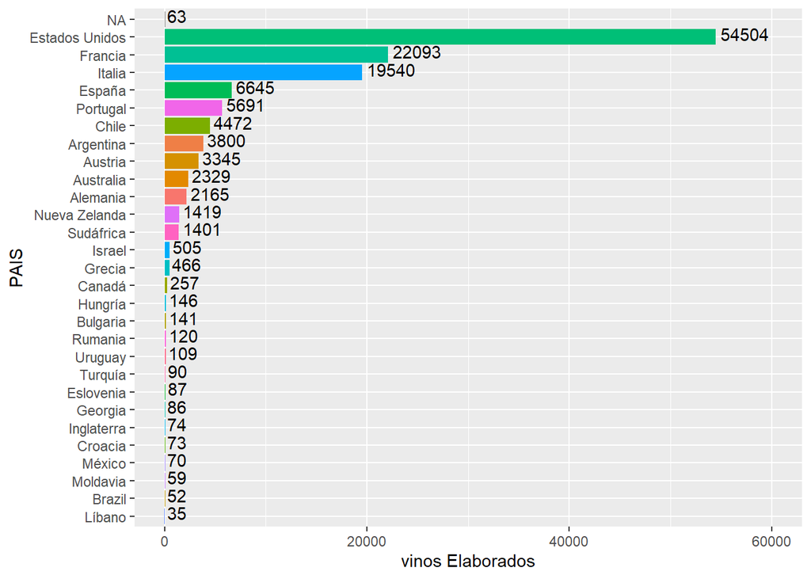

```r
ggplot(vinos_pais,aes(reorder(pais, n), n, fill= pais)) +
  geom_bar(stat="identity") +
  geom_text(aes(label=n), hjust=-.1, vjust=.25) +
  xlab("PAIS") +
  ylab("vinos Elaborados") +
  ylim(0, 60000) +
  guides(fill="none")+
  coord_flip()
```

Tomamos estos tres paises para comparar en términos de puntos.

```r
EEUU_Francia_Italia <- filter(vinos, pais  %in%  c("Estados Unidos","Francia","Italia"))
```

Se usará un diagrama de caja que también incluye la media.

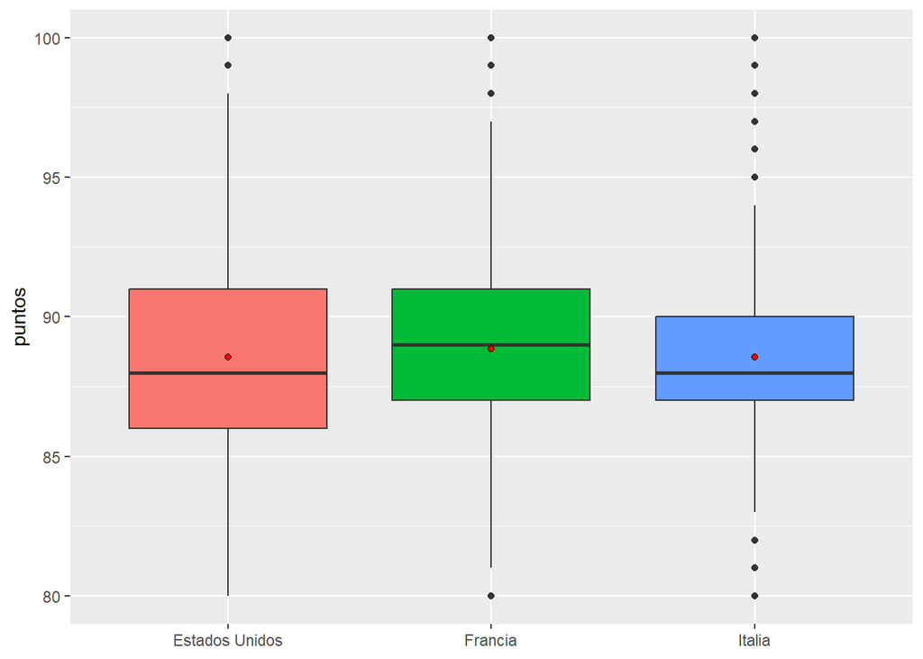

```r
ggplot(EEUU_Francia_Italia, mapping= aes(pais,puntos, fill=pais))+
  geom_boxplot()+
  stat_summary(fun.y="mean", geom="point", shape=21, fill= "red") +
  scale_x_discrete(labels=c("Estados Unidos","Francia", "Italia")) +
  guides(fill=FALSE) +
  theme(axis.title.x=element_blank())
```

Es interesante notar que tanto Italia como EEUU tienen medias más altas que las medianas, lo que significa que tienen unos pocos vinos selectos excepcionales, mientras que Francia tiene casi exactamente la misma mediana y media, las cuales son más altas que Italia y EEUU, lo que significa que Francia posee vinos de mejor calidad (puntuación).